# Capston Project: Exploratory Data Analysis Milestone

Bojan Brajkovic

21/10/2018

### Introduction to Analysis

The goal of this project is just to display that student is used to working with the data and is on track to create prediction algorithm. Report, should be submitted in RPubs, that explains exploratory analysis and goals for the eventual app and algorithm. This document should be concise and explain only the major features of the data identified and briefly summarize plans for creating the prediction algorithm and Shiny app in a way that would be understandable to a non-data scientist manager. Tables and plots should be used to illustrate important summaries of the data set.

The motivation for this project is to: 1. Demonstrate that you’ve downloaded the data and have successfully loaded it in. 2. Create a basic report of summary statistics about the data sets. 3. Report any interesting findings that you amassed so far. 4. Get feedback on your plans for creating a prediction algorithm and Shiny app.

##### Review criteria

1. Does the link lead to an HTML page describing the exploratory analysis of the training data set?
2. Has the data scientist done basic summaries of the three files? Word counts, line counts and basic data tables?
3. Has the data scientist made basic plots, such as histograms to illustrate features of the data?
4. Was the report written in a brief, concise style, in a way that a non-data scientist manager could appreciate?

### Loading and downloading the data

##### Data download

```r
if (!file.exists("./data/final")) {
  if (!file.exists("./data/Coursera-SwiftKey.zip")) {
    download.file("https://d396qusza40orc.cloudfront.net/dsscapstone/dataset/Coursera-SwiftKey.zip",
                  destfile = "Coursera-SwiftKey.zip", quiet=TRUE)
  }

  unzip("Coursera-SwiftKey.zip", exdir = "./data");
}
```

##### Data Load

```r
setwd("~/Desktop/Capstone")
twitter <- readLines(connection <- file("data/final/en_US/en_US.twitter.txt"), encoding = "UTF-8", skipNul = TRUE)
close(connection)
blogs <- readLines(connection <- file("data/final/en_US/en_US.blogs.txt"), encoding = "UTF-8", skipNul = TRUE)
close(connection)
news <- readLines(connection <- file("data/final/en_US/en_US.news.txt"), encoding = "UTF-8", skipNul = TRUE)
close(connection)
rm(connection)
```

### Summary of data

Review criteria: Has the data scientist done basic summaries of the three files? Word counts, line counts and basic data tables?

```
##                             dataFile Size(MB) linesNumber Max Line Length
## 1    data/final/en_US/en_US.news.txt   196.28     1010242          123628
## 2   data/final/en_US/en_US.blogs.txt   200.42      899288          483415
## 3 data/final/en_US/en_US.twitter.txt   159.36     2360148              26
##   WordCount
## 1  34372814
## 2  37334149
## 3  30373605
```

### Data Analysis

Review criteria: Has the data scientist made basic plots, such as histograms to illustrate features of the data?

##### US news dataset plot

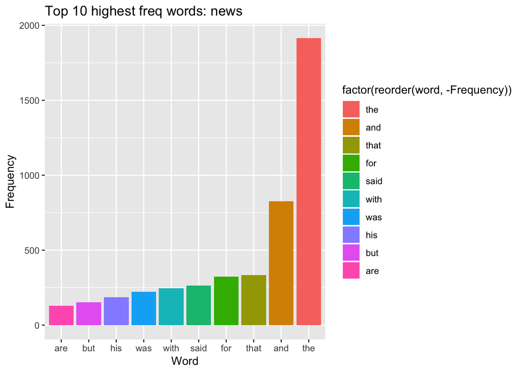

##### US twitter dataset plot

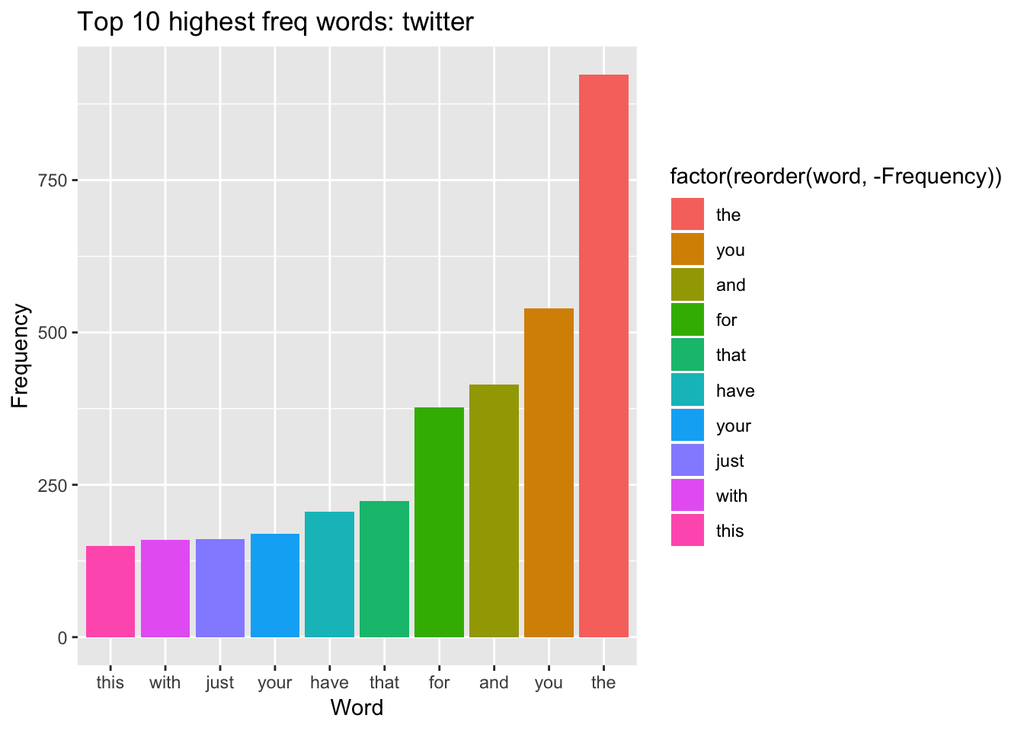

##### US blogs dataset plot

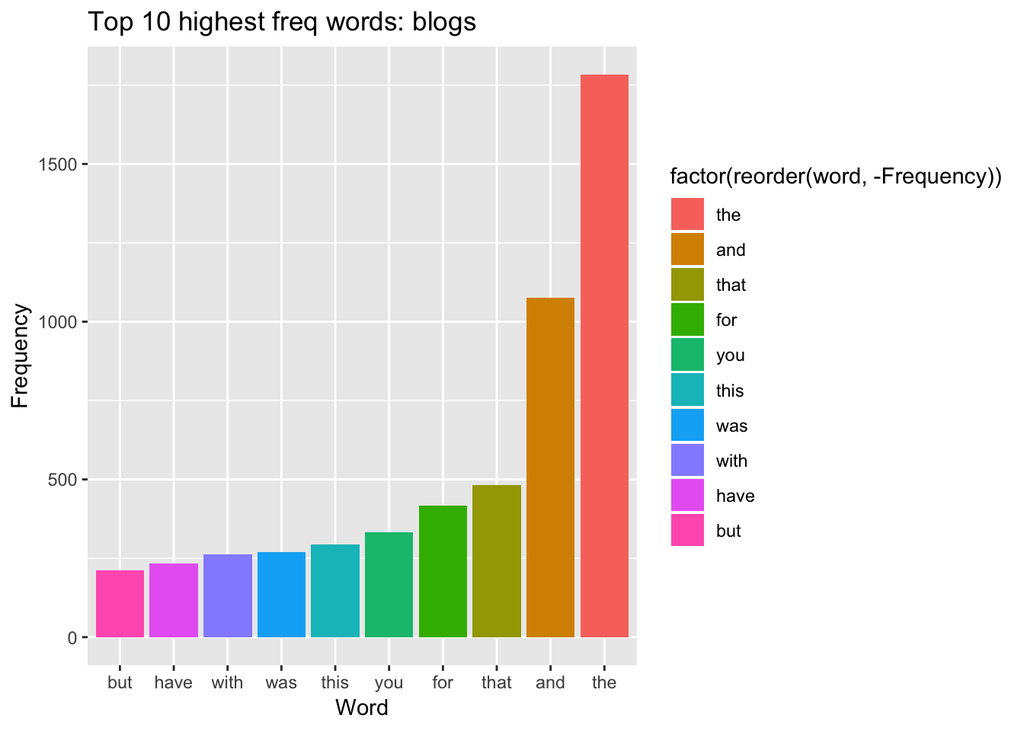

##### N-grams News

```
##   said    one    new    can    two   year   also   time  first   just
##   2514    793    657    600    599    573    561    541    531    528
##  state people   like   last  years    get   city school    now  going
##    519    509    508    484    465    458    378    372    363    354
```

```
##       last_year        new_york        st_louis     high_school
##             127             110              96              83
##       years_ago      new_jersey       last_week     los_angeles
##              79              79              69              59
##       two_years   united_states      first_time     three_years
##              43              42              42              41
##   san_francisco school_district     health_care  officials_said
##              41              37              37              36
##      last_month         a.m_p.m law_enforcement  vice_president
##              35              35              34              33
```

```
##               st_louis_county        president_barack_obama
##                            21                            17
##                 two_years_ago                 new_york_city
##                            15                            12
##            gov_chris_christie       chief_operating_officer
##                             8                             8
##         senior_vice_president            nearly_three_years
##                             7                             7
##    county_prosecutor's_office               cents_per_share
##                             7                             7
##                new_york_times          superior_court_judge
##                             7                             7
## former_massachusetts_governor               three_years_ago
##                             6                             6
##              first_time_since               new_york_knicks
##                             6                             5
##                   rock_n_roll               health_care_law
##                             5                             5
##      executive_vice_president      law_enforcement_officers
##                             5                             5
```

##### N-grams Twitter

```
##   just   like   good    get   love     rt    day thanks    can    now
##   1504   1197   1090   1079   1050    939    934    928    886    862
##      u   know   time    one  great     go  today    lol    new    see
##    809    806    775    773    770    712    701    690    689    665
```

```
##       right_now      last_night    good_morning looking_forward
##             169             113              93              89
##  happy_birthday      looks_like   thanks_follow       feel_like
##              83              83              77              76
##       good_luck        just_got        let_know       thanks_rt
##              68              65              56              54
##      first_time      thank_much     follow_back         can_get
##              51              48              45              45
##   please_follow       next_week       great_day      stay_tuned
##              43              42              40              38
```

```
##         happy_new_year         duke_duke_duke            let_us_know
##                     22                     20                     19
##      happy_mothers_day          hate_job_hate           job_hate_job
##                     16                     11                     10
##   please_please_please    thanks_following_us         keep_good_work
##                     10                      9                      9
##          cinco_de_mayo         hope_great_day          just_got_back
##                      8                      8                      8
##               la_la_la                s_o_new     happy_mother's_day
##                      8                      7                      7
## looking_forward_seeing          just_got_done          just_let_know
##                      7                      6                      6
##         add_boston_add      boston_add_boston
##                      6                      6
```

##### N-grams Blogs

```
##    one   just    can   like   time    get   know    now people    new
##   1256   1014   1001    957    845    724    631    600    586    558
##   also  first   back    day   even    see   good  think   well   love
##    557    518    510    509    505    499    498    495    491    489
```

```
##          amp_amp        years_ago           amp_gt        right_now
##              262               60               59               57
##        feel_like       first_time           amp_lt          lt_span
##               49               48               46               46
##      even_though         new_york          can_see        every_day
##               44               43               41               39
##        make_sure        one_thing          can_get        last_year
##               37               33               32               31
##          one_day      pretty_much style_background  background_none
##               31               30               30               30
```

```
##                       amp_amp_amp                        amp_amp_gt
##                               157                                59
##                        amp_amp_lt                       amp_lt_span
##                                46                                46
##             style_background_none            background_none_repeat
##                                30                                30
##                none_repeat_scroll              repeat_scroll_yellow
##                                30                                30
##               scroll_yellow_class             span_style_background
##                                29                                29
##                      span_amp_amp yellow_class_goog-spellcheck-word
##                                28                                23
##    class_goog-spellcheck-word_amp      goog-spellcheck-word_amp_amp
##                                23                                23
##                       lt_span_amp                     lt_span_style
##                                23                                23
##                        amp_gt_amp                        gt_amp_amp
##                                18                                18
##                         amp_gt_lt                         gt_lt_amp
##                                13                                13
```

### Conclusion

##### Interesting findings

Resources needed to process data are quite demanding and I had to do a lot of testing in order to get analysis to perform well. I had to sample data as well, where in some occurances there is around 1% of data used.

##### Next steps

- Create prediction model alghoritm with a larger sample.
- Build larger n-grams
- Create Shiny app to create better predictionc